# HW 1: OLS Review

Advanced Regression (STAT 353-0)

Author

Hanyu Su

Published

January 14, 2025

**Github Repo Link**

To link to your github **repo**sitory, appropriately edit the example link below. Meaning replace `https://your-github-repo-url` with your github repo url. Suggest verifying the link works before submitting.

https://github.com/stat-353-0-2025-winter/hw-1-ols-review-DeanshyNU

## Overview

In this homework, you will review OLS regression. The concepts focused on here are obviously not all of what you know (from STAT 350), but they are concepts that are particularly important for this course. Pay particular attention to interpretation.

## Data

For this assignment, we are using the `Duncan` dataset. This dataset provides data on the prestige and other characteristics of 45 U. S. occupations in 1950. The data was collected by the sociologist [Otis Dudley Duncan](https://en.wikipedia.org/wiki/Otis_Dudley_Duncan).

## Preliminaries

As a first step, we load the `{car}` package. This is the package developed by the author of our textbook and contains several useful functions and datasets, so we will be using it throughout this quarter.

Begin by examining the first few rows of the `Duncan` data:

```r
library("car")

head(Duncan, n=10)
```

```
           type income education prestige
accountant prof     62        86       82
pilot      prof     72        76       83
architect  prof     75        92       90
author     prof     55        90       76
chemist    prof     64        86       90
minister   prof     21        84       87
professor  prof     64        93       93
dentist    prof     80       100       90
reporter     wc     67        87       52
engineer   prof     72        86       88
```

```r
dim(Duncan)
```

```
[1] 45  4
```

Obtain summary statistics for the variables in `Duncan`:

```r
summary(Duncan)
```

```
   type        income        education         prestige
 bc  :21   Min.   : 7.00   Min.   :  7.00   Min.   : 3.00
 prof:18   1st Qu.:21.00   1st Qu.: 26.00   1st Qu.:16.00
 wc  : 6   Median :42.00   Median : 45.00   Median :41.00
           Mean   :41.87   Mean   : 52.56   Mean   :47.69
           3rd Qu.:64.00   3rd Qu.: 84.00   3rd Qu.:81.00
           Max.   :81.00   Max.   :100.00   Max.   :97.00
```

As a first graph, we view a histogram of the variable `prestige`:

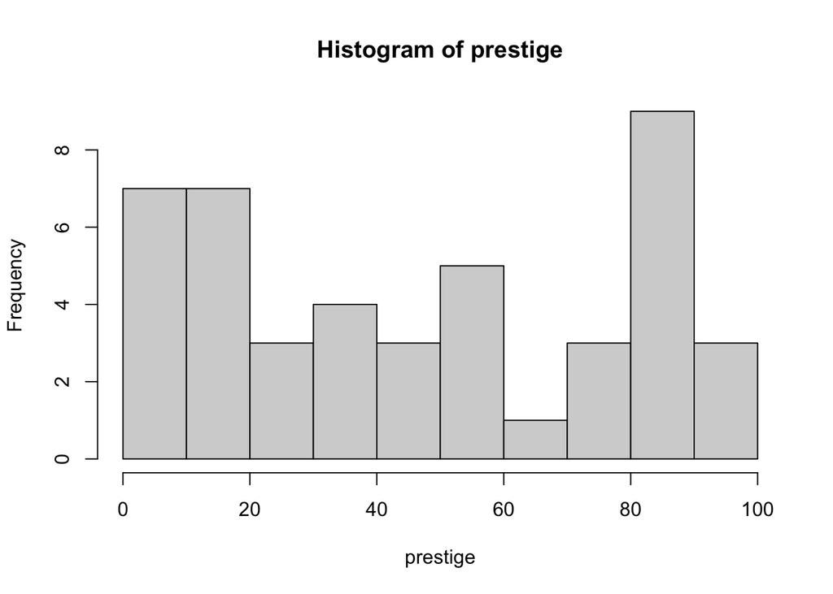

```r
with(Duncan, hist(prestige))
```

## Exercises

### 1. Examining the Data

A first step for any analysis should include Exploratory Data Analysis (EDA). This allows you to check to see that you understand the variables - how they are coded, if they are factors or continuous, and if there are mistakes.

**Solution**

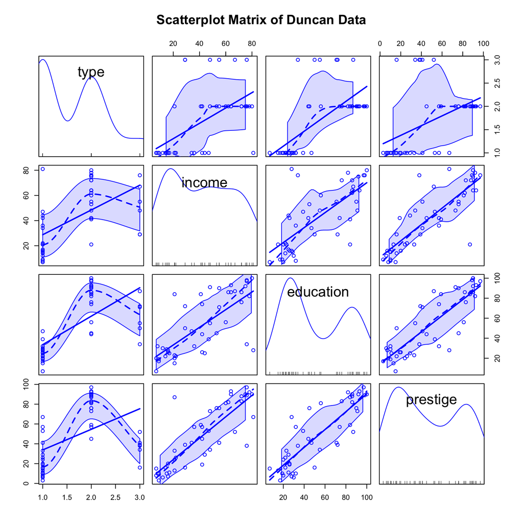

```r
scatterplotMatrix(Duncan, main = "Scatterplot Matrix of Duncan Data")
```

```r
sapply(Duncan, class)
```

```
     type    income education  prestige
 "factor" "integer" "integer" "integer"
```

```r
summary(Duncan)
```

```
   type        income        education         prestige
 bc  :21   Min.   : 7.00   Min.   :  7.00   Min.   : 3.00
 prof:18   1st Qu.:21.00   1st Qu.: 26.00   1st Qu.:16.00
 wc  : 6   Median :42.00   Median : 45.00   Median :41.00
           Mean   :41.87   Mean   : 52.56   Mean   :47.69
           3rd Qu.:64.00   3rd Qu.: 84.00   3rd Qu.:81.00
           Max.   :81.00   Max.   :100.00   Max.   :97.00
```

Via the scatterplots above - and any other EDA you’d like to do - describe the data. What seems to be going on here?

**Solution**

### 2. Regression Analysis

#### A. Model 1

Use the`lm()` function to fit a linear regression model to the data, in which `education` and `income` are regressed on `prestige`.

Interpret the findings from this model. Are education and income good explanations for an occupation’s prestige? Interpret the coefficient for income - what does it mean? Does education or income have a larger effect on prestige? Justify your conclusion.

**Solution**

From the output we can see that R^2 is 0.8282 and the F statistics is 101.2 with corresponding p value < 2.2e-16 hence income and education are good explanations for prestige. And their p-values are both very significant.  
The coefficient for income is 0.59873 which means that at a fixed level of education, a unit of increase in income is expected to cause 0.59873 increase in prestige. It means that there is a positive relationship between prestige and income.  
The coefficients for education and income are 0.54583 and 0.59873 with corresponding p-values 1.73e-06 and 1.05e-05 respectively. Although the coefficient of income is larger than that of education, the p-value of education is smaller which means education is more stable. So basically, I think they have roughly the same effect on prestige.

```r
model1 <- lm(prestige ~ education + income, data = Duncan)
summary(model1)
```

```
Call:
lm(formula = prestige ~ education + income, data = Duncan)

Residuals:
    Min      1Q  Median      3Q     Max
-29.538  -6.417   0.655   6.605  34.641

Coefficients:
            Estimate Std. Error t value Pr(>|t|)
(Intercept) -6.06466    4.27194  -1.420    0.163
education    0.54583    0.09825   5.555 1.73e-06 ***
income       0.59873    0.11967   5.003 1.05e-05 ***
---
Signif. codes:  0 '***' 0.001 '**' 0.01 '*' 0.05 '.' 0.1 ' ' 1

Residual standard error: 13.37 on 42 degrees of freedom
Multiple R-squared:  0.8282,    Adjusted R-squared:   0.82
F-statistic: 101.2 on 2 and 42 DF,  p-value: < 2.2e-16
```

#### B. Model 2

Now, add in the `type` of occupation to the model. Is the model with `type` a better model? Explain what statistics you would use to make this decision, conduct the analysis, and interpret the results.

**Solution**

Yes, model2 is a better model than model1. There are many different indices that support this conclusion. First, the adjusted R^2 of model2 is higher than that of model1. Second, by using the ANOVA, we get a very small p value which also means that model2 explains more than model1. Third, by checking the AIC and BIC, we can see that these two indices of model2 are lower that that of model1 which also proves the conclusion.

```r
model2 <- lm(prestige ~ education + income + type, data = Duncan)
summary(model2)
```

```
Call:
lm(formula = prestige ~ education + income + type, data = Duncan)

Residuals:
    Min      1Q  Median      3Q     Max
-14.890  -5.740  -1.754   5.442  28.972

Coefficients:
             Estimate Std. Error t value Pr(>|t|)
(Intercept)  -0.18503    3.71377  -0.050  0.96051
education     0.34532    0.11361   3.040  0.00416 **
income        0.59755    0.08936   6.687 5.12e-08 ***
typeprof     16.65751    6.99301   2.382  0.02206 *
typewc      -14.66113    6.10877  -2.400  0.02114 *
---
Signif. codes:  0 '***' 0.001 '**' 0.01 '*' 0.05 '.' 0.1 ' ' 1

Residual standard error: 9.744 on 40 degrees of freedom
Multiple R-squared:  0.9131,    Adjusted R-squared:  0.9044
F-statistic:   105 on 4 and 40 DF,  p-value: < 2.2e-16
```

```r
anova(model1, model2)
```

```
Analysis of Variance Table

Model 1: prestige ~ education + income
Model 2: prestige ~ education + income + type
  Res.Df    RSS Df Sum of Sq     F    Pr(>F)
1     42 7506.7
2     40 3798.0  2    3708.7 19.53 1.208e-06 ***
---
Signif. codes:  0 '***' 0.001 '**' 0.01 '*' 0.05 '.' 0.1 ' ' 1
```

```r
AIC(model1, model2)
```

```
       df      AIC
model1  4 365.9645
model2  6 339.3045
```

```r
BIC(model1, model2)
```

```
       df      BIC
model1  4 373.1911
model2  6 350.1444
```

### 3. Regression Diagnostics

#### A. Non-normality

The `rstudent()` function returns studentized residuals, and the `densityPlot()` function fits an adaptive kernel density estimator to the distribution of the studentized residuals. A `qqPlot()` can be used as a check for nonnormal errors, comparing the studentized residuals to a t-distribution.

Use these to examine the results of your best model from Question 2. What do you conclude?

**Solution**

From the Kernel Density Plot of Studentized Residuals, we can see that it roughly follows a t distribution. But we can also see there is a heavy right tail indicating positive skewness.  
From the QQ-plot, we can see that the studentized residuals are align with t distribution with machinist and minister two outliers.  
Therefore we can say that model2 is indeed a nice model but we can pay more attention to the positive skewness and outliers problem for further interest.

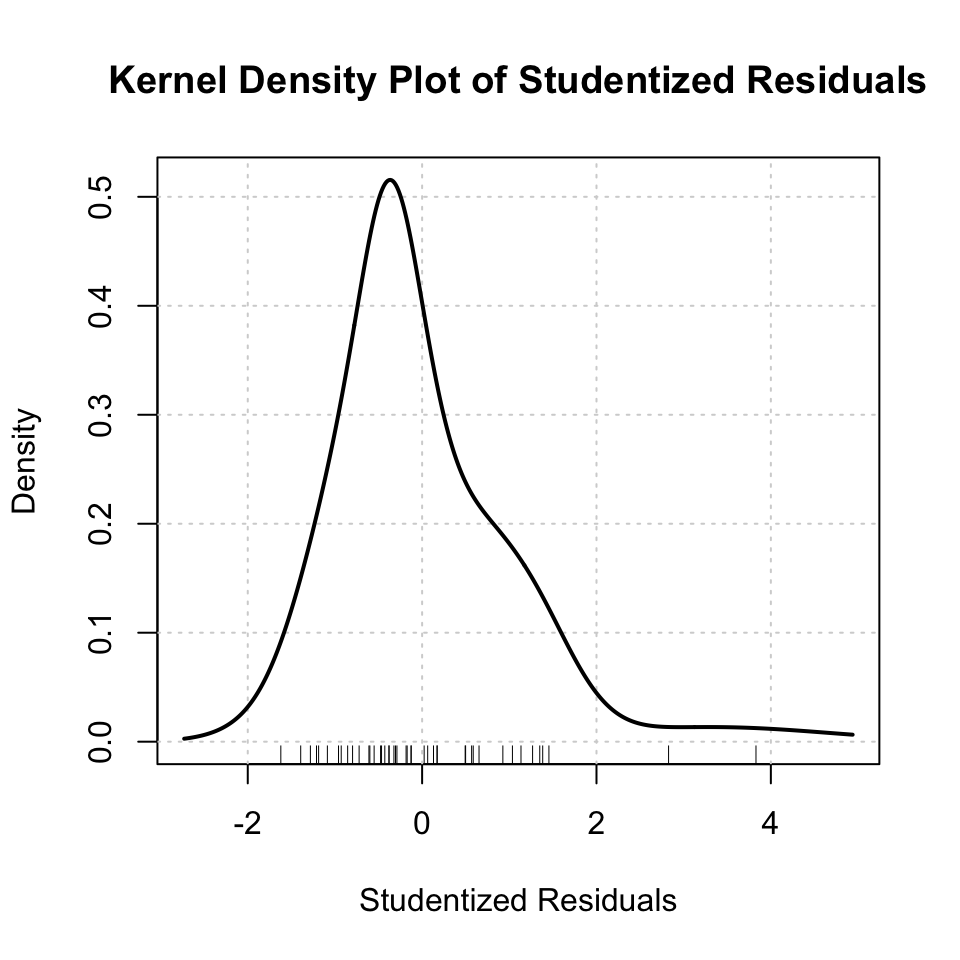

```r
studentized_residuals <- rstudent(model2)
densityPlot(studentized_residuals,
            main = "Kernel Density Plot of Studentized Residuals",
            xlab = "Studentized Residuals")
```

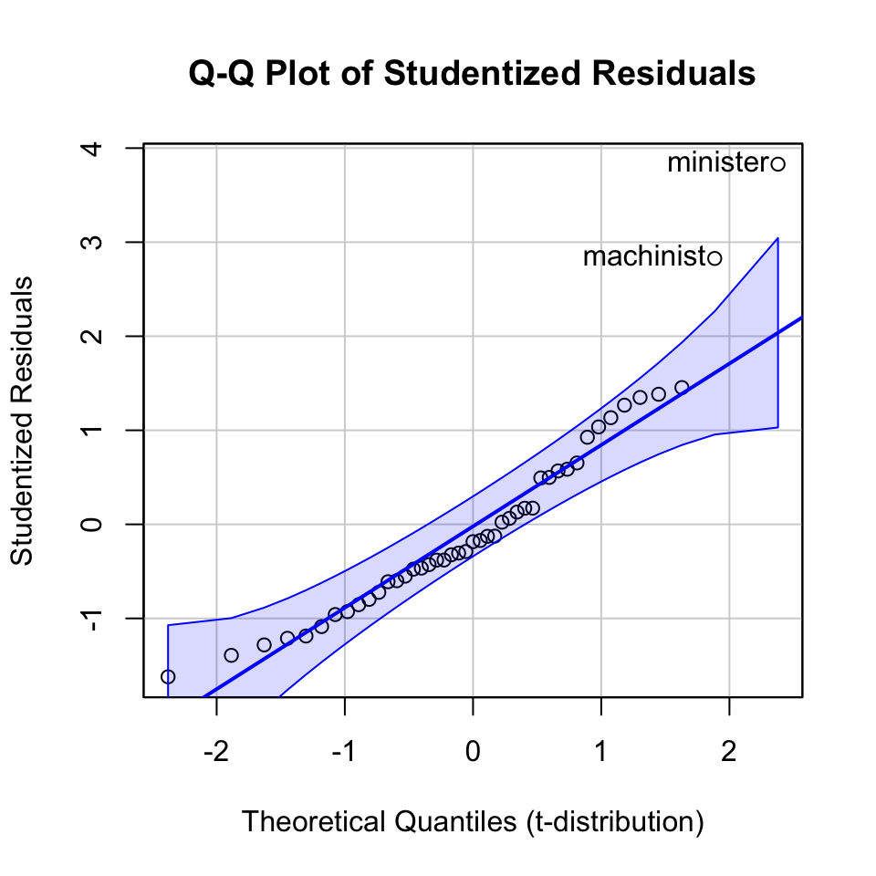

```
 minister machinist
        6        28
```

```r
qqPlot(studentized_residuals,
       distribution = "t",
       df = 40,
       main = "Q-Q Plot of Studentized Residuals",
       xlab = "Theoretical Quantiles (t-distribution)",
       ylab = "Studentized Residuals")
```

#### B. Influence = outliers * leverage

The `outlierTest()` function tests for outliers in the regression. The `influenceIndexPlot()` function creates a graph that displays influence measures in index plots. The `avPlots()` function creates added variable plots, which allow you to visualize how influential data points might be affecting (or not) the estimated coefficients.

Using these (and/or other tools), using your preferred model from Question 2, are there any influential data points?

If the diagnostics suggest that there are influential points, does removing these influential points change the results of the analysis? Compare models using the `compareCoefs()` function. What do you conclude?

**Solution**

After removing `minister` and `machinist`, we observe that all coefficients are affected by the removal of these two data points, with changes in different directions. Additionally, the standard errors of all coefficients decreased, indicating that the removal of these two influential points made the model more stable and improved the precision of the coefficient estimates.

```r
outlier_test <- outlierTest(model2)
print(outlier_test)
```

```
         rstudent unadjusted p-value Bonferroni p
minister 3.829396         0.00045443      0.02045
```

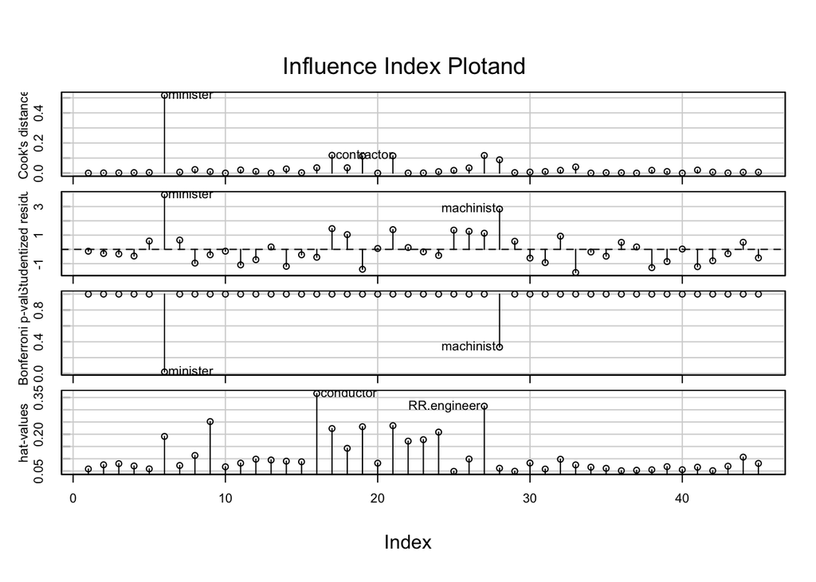

```r
influenceIndexPlot(model2, main = "Influence Index Plotand ")
```

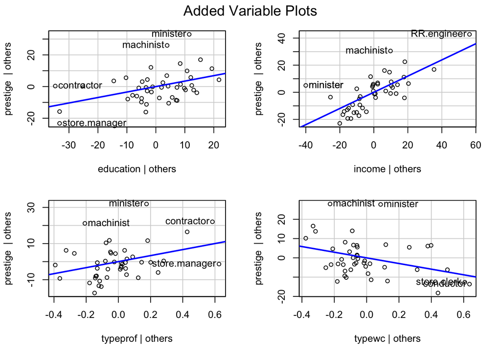

```r
avPlots(model2, main = "Added Variable Plots")
```

```r
Duncan_no_minister_machinist <- Duncan[!rownames(Duncan) %in% c("minister", "machinist"), ]
model3 <- lm(prestige ~ education + income + type, data = Duncan_no_minister_machinist)
compareCoefs(model2, model3)
```

```
Calls:
1: lm(formula = prestige ~ education + income + type, data = Duncan)
2: lm(formula = prestige ~ education + income + type, data =
  Duncan_no_minister_machinist)

            Model 1 Model 2
(Intercept)  -0.185  -1.959
SE            3.714   2.902

education    0.3453  0.2775
SE           0.1136  0.0892

income       0.5975  0.6943
SE           0.0894  0.0752

typeprof      16.66   16.21
SE             6.99    5.54

typewc       -14.66  -13.61
SE             6.11    4.80
```

#### C. Non-linearity

Component-plus-residual plots allow for the detection of non-linearity in the partial relationship between each covariate and the outcome. These can be created using the `crPlots()` function.

For your preferred model, does it appear there is any nonlinearity? Explain.

**Solution**

From the plots we can observe that generally there is no nonlinearity, but there maybe some nonliearity at lower level of education.

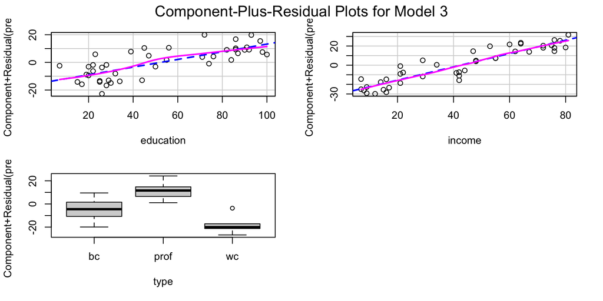

```r
crPlots(model3, main = "Component-Plus-Residual Plots for Model 3")
```

#### D. Heteroscedasticity

Non-constant error variance can be tested using the `ncvTest()` function.

Does it appear that this is a concern with this data? Explain

**Solution**

Based on the output, the p-value of 0.3534 indicates that there is no significant evidence of heteroscedasticity in the model. We can assume that the error variance is constant, and heteroscedasticity is not a concern with this data.

```r
ncvTest(model3)
```

```
Non-constant Variance Score Test
Variance formula: ~ fitted.values
Chisquare = 0.8612201, Df = 1, p = 0.3534
```

### 4. Interpretation

Should the model above be used to answer a descriptive, explanatory, or predictive question? Explain your answer.

**Solution**

The model should be used to answer explanatory question. For descriptive questions, we need summary statistics like mean, median and variance, so this is not needed for such questions. The coefficients, test statistics, p-values are all great indices to explain the influence of the variables, hence the model is a great method for explanatory problem. For prediction problem, we have not made any explorations on its prediction accuracy like cross-validation. Therefore, it is better not to be used for prediction at this stage.